# Fashion MNIST PCA

## PCA

We have shown above that there is redundancy in the fashion MNIST dataset. Here we will use PCA to reduce the number of features while retaining as much of the variance possible. PCA does this by finding a new set of axes that fit to the variance of the data. At heart, PCA is simply an eigendecomposition of the data which returns a set of eigenvectors and eigenvalues. Eigenvectors and eigenvalues describe the transformations necessary to go from the original axes to a new feature space.

We can use the results of PCA to perform a type of information compression on the original data by subsetting the amount of PCA components we use to describe the original data. For this analysis, we will use a criterion of 95% variance explained. From the 784 components that PCA yields, we will subset the minimum components needed such that the sum of the proportions of explained variance is greater than or equal to 95%. Such a manipulation is favorable because it will reduce the data redundance, the chances of overfitting, and the time necessary to train models.

```r
# use the prcomp function
train.pca <- prcomp( train )
# pca summary
sumTrain <- summary( train.pca )
#calculate total variance explained by each principal component
df_pca <- data.frame( t( sumTrain$importance ) )
df_pca$compnum <- 1:dim(train)[2]
```

How many components account for 95% of the variance in the data?

```r
comp95 <- min(which(df_pca$Cumulative.Proportion>=0.95))
comp95
```

```
## [1] 187
```

Visualizing the cumulative explained variance described by the principal components with a Skree Plot:

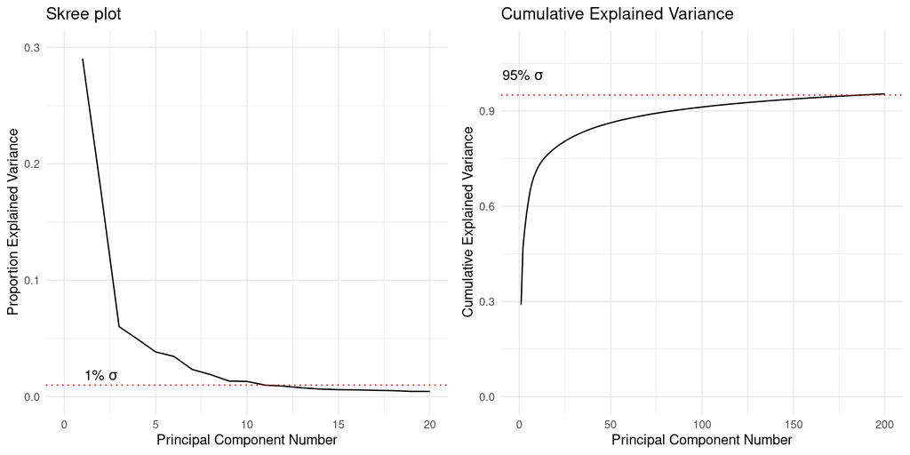

```r
p1 <- ggplot( df_pca, aes( x = compnum, y = Proportion.of.Variance ) ) +
  geom_line() +
  ylim( c(0,0.3) ) +
  xlim( c(0,20)) +
  geom_hline( yintercept = 0.01, linetype = 'dotted', col = 'red') +
  annotate("text", x = 2, y = 0.01,
           label = expression( "1%" ~ sigma), vjust = -0.5) +
  theme_minimal() +
  xlab( 'Principal Component Number' ) +
  ylab( 'Proportion Explained Variance' ) +
  ggtitle( 'Skree plot' )

p2 <- ggplot( df_pca, aes( x = compnum, y = Cumulative.Proportion ) ) +
  geom_line() +
  ylim( c(0,1.1) ) +
  xlim( c(0,200)) +
  geom_hline( yintercept = 0.95, linetype = 'dotted', col = 'red') +
  annotate("text", x = 2, y = 0.98,
           label = expression( "95%" ~ sigma), vjust = -0.5) +
  theme_minimal() +
  xlab( 'Principal Component Number' ) +
  ylab( 'Cumulative Explained Variance' ) +
  ggtitle( 'Cumulative Explained Variance' )

grid.arrange( p1, p2, ncol=2)
```

From the skree plot, we can see a very sharp drop off in the proportion of explained variance. Principal Components greater than 12 account for less than 1% of the dataset’s variance. The first 12 components only account for a cumulative variance of 0.74, therefore it takes the combined contribution of many more components (187 components) to explain 95% of the variance of each pixel for the original images.

Visualizing several PCA components

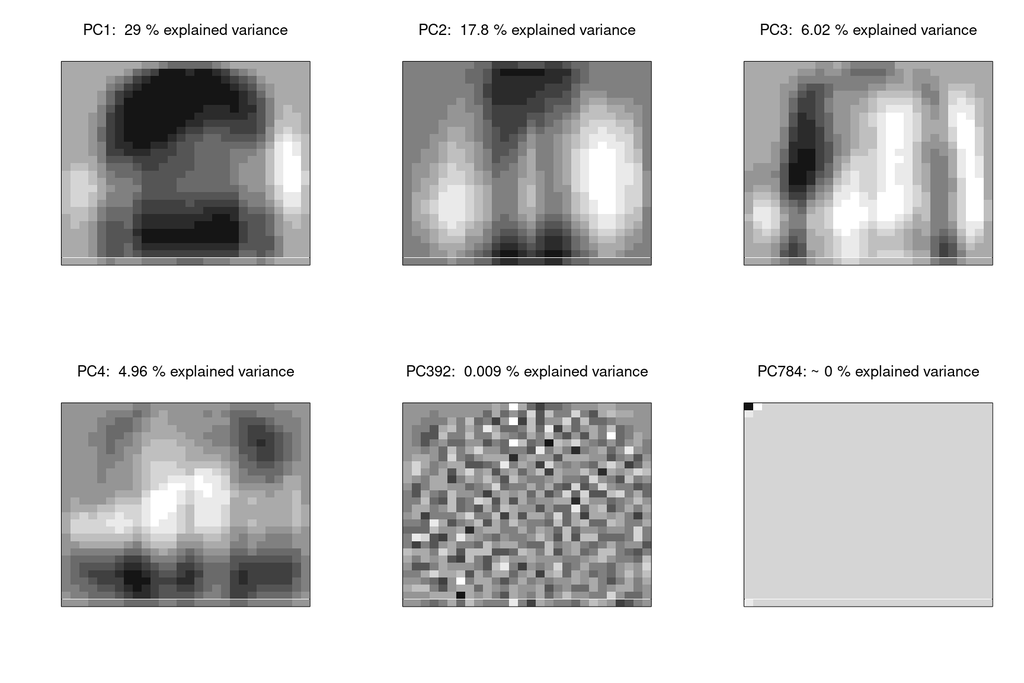

```r
par(mfrow = c(2,3))

show_digit(sumTrain$rotation[,1])
title(bquote('PC1: ' ~ .(round( df_pca$Proportion.of.Variance[1],3)*100) ~ '% explained variance'))

show_digit(sumTrain$rotation[,2])
title(bquote('PC2: ' ~ .(round( df_pca$Proportion.of.Variance[2],3)*100) ~ '% explained variance'))

show_digit(sumTrain$rotation[,3])
title(bquote('PC3: ' ~ .(round( df_pca$Proportion.of.Variance[3],4)*100) ~ '% explained variance'))

show_digit(sumTrain$rotation[,4])
title(bquote('PC4: ' ~ .(round( df_pca$Proportion.of.Variance[4],4)*100) ~ '% explained variance'))

show_digit(sumTrain$rotation[,392])
title(bquote('PC392: ' ~ .(round( df_pca$Proportion.of.Variance[392],6)*100) ~ '% explained variance'))

show_digit(sumTrain$rotation[,784])
title(bquote('PC784: ~' ~ .(df_pca$Proportion.of.Variance[784]) ~ '% explained variance'))
```

```r
par(mfrow = c(1,1))
```

PC1 and PC2 account for roughly half (0.47) of the train dataset’s variance. We can visualize the projections of the train data onto the features space of these two components:

```r
label = c('T-shirt/top', 'Trouser', 'Pullover', 'Dress', 'Coat', 'Sandal', 'Shirt', 'Sneaker', 'Bag', 'Ankle boot')

train_pca_x <- data.frame(train.pca$x) %>%
  select( c( 'PC1', 'PC2' ) ) %>%
  mutate( labels = train_y,
          labels_text = case_when( labels == 0 ~ 'T-shirt/top',
                                   labels == 1 ~ 'Trouser',
                                   labels == 2 ~ 'Pullover',
                                   labels == 3 ~ 'Dress',
                                   labels == 4 ~ 'Coat',
                                   labels == 5 ~ 'Sandal',
                                   labels == 6 ~ 'Shirt',
                                   labels == 7 ~ 'Sneaker',
                                   labels == 8 ~ 'Bag',
                                   labels == 9 ~ 'Ankle boot') )
cat_mean <- train_pca_x %>%
  group_by( labels_text ) %>%
  summarise( PC1_mean = mean( PC1 ),
             PC2_mean = mean( PC2 ) )
cat_mean
```

```
## # A tibble: 10 × 3
##    labels_text PC1_mean PC2_mean
##    <chr>          <dbl>    <dbl>
##  1 Ankle boot    -558.   -1101.
##  2 Bag             43.7   -880.
##  3 Coat          1059.    -211.
##  4 Dress          283.    1043.
##  5 Pullover       862.    -331.
##  6 Sandal       -1499.    -120.
##  7 Shirt          584.      39.7
##  8 Sneaker      -1475.    -404.
##  9 T-shirt/top    686.     610.
## 10 Trouser         15.7   1355.
```

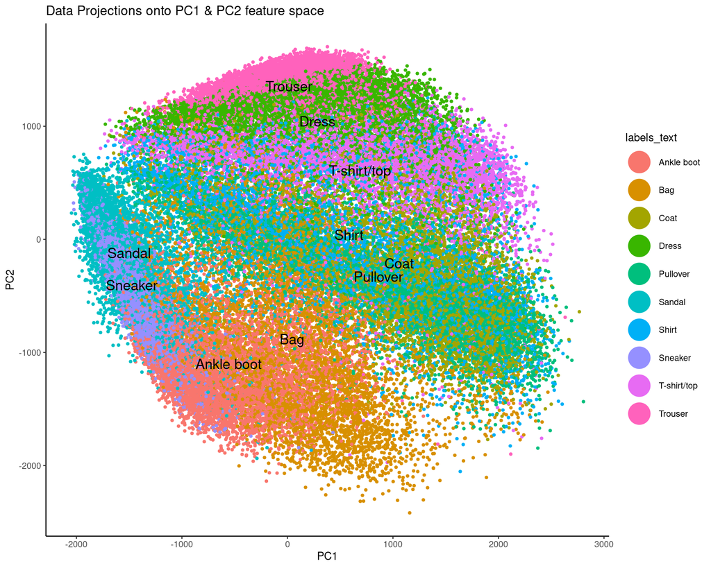

```r
ggplot( train_pca_x, aes( x = PC1, y = PC2, color = labels_text)) +
  geom_point( size = 1 ) +
  theme_classic() +
  geom_text(data=cat_mean, aes( x = PC1_mean, y = PC2_mean, label = labels_text),
            color = 'black', size = 5 ) +
  guides(colour = guide_legend(override.aes = list(size=10))) +
  ggtitle( 'Data Projections onto PC1 & PC2 feature space' )
```

The figure above shows the representations of the `train` images in the feature space of the first 2 dimensions. Each clothing item category is represented by a different color. For clarity, a text label (in black) which corresponds to the categorical mean values of PC1 & PC2 has been added. We can see that there is noticeable separation across the categories. Additionally, we see some clustering of category means that meets expectations. For example, the shoe categories (Sandal, Sneaker and Ankle Boot) group together towards the lower left hand corner of the figure. Clothing items that could all be described as tops with sleeves ( Pullover, Coat, Shirt & T-shirt/top) group together in the middle of the distribution. Trousers, on the other hand, have a noticeable distance from tops with sleeves but ar contiguous with the dress category which shares roughly vertical rectangular profile.

Let us now visualize the image representations in the 2 dimensional PC1 and PC2 feature space:

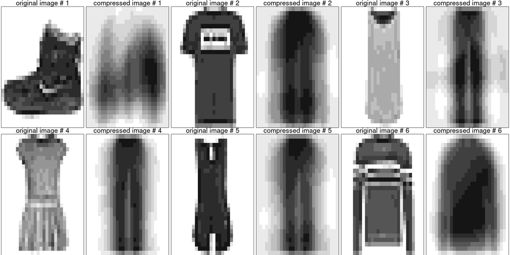

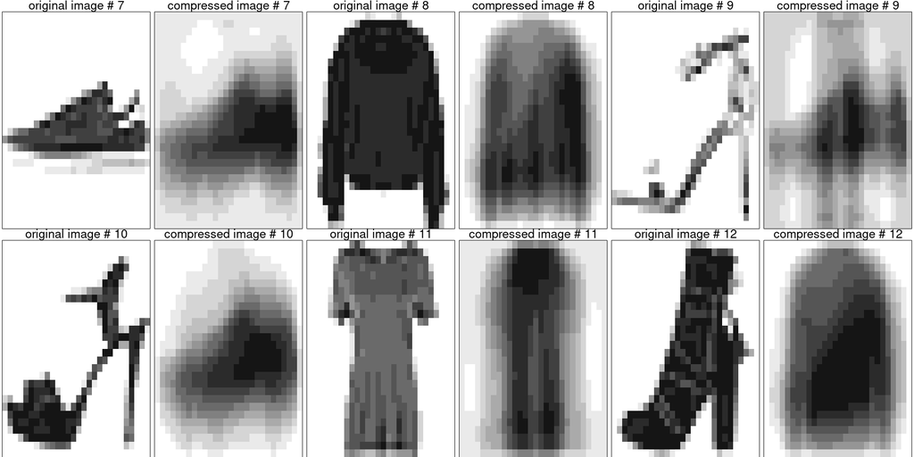

```r
trunc <- train.pca$x[,1:2] %*% t(train.pca$rotation[,1:2])

#and add the center (and re-scale) back to data
if(train.pca$scale != FALSE){
    trunc <- scale(trunc, center = FALSE , scale=1/train.pca$scale)
}
if(train.pca$center != FALSE){
    trunc <- scale(trunc, center = -1 * train.pca$center, scale=FALSE)
}

npics = 6
mpics = 2
par(mfrow=c(mpics, npics), mar=c(0, 0.2, 1, 0.2))
for (i in 1:(npics*mpics)) {
  show_digit(train[i, ])
  title(bquote('original image #' ~ .(i) ))
  show_digit(trunc[i, ])
  title(bquote('compressed image #' ~ .(i) ))
}
```

The figures above show the original images next to the projections into the compressed PC1+PC2 feature space. With only 2 components, we can see that the representation is not completely lost for all images. For instance, The images for pullovers (Image #6 and #8) are both recognizable as pullovers. However, the representations of Dress images are confounded by PC2 which is tuned to discriminate Trousers. Additionally, many of the representations of shoes are quite ambiguous.

Clearly more features are necessary to represent the variance in the data.

Here we find the representation onto the first 187 components which were shown earlier to account for 95% of the variance in the image data:

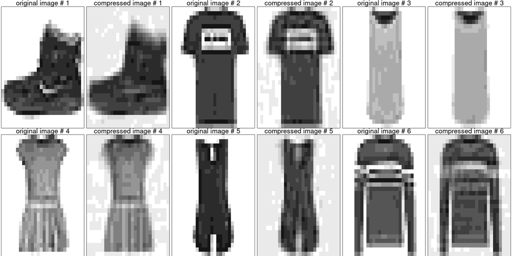

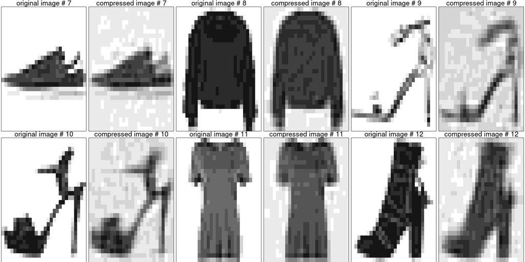

```r
trunc <- train.pca$x[,1:comp95] %*% t(train.pca$rotation[,1:comp95])

#and add the center (and re-scale) back to data
if(train.pca$scale != FALSE){
    trunc <- scale(trunc, center = FALSE , scale=1/train.pca$scale)
}
if(train.pca$center != FALSE){
    trunc <- scale(trunc, center = -1 * train.pca$center, scale=FALSE)
}

npics = 6
mpics = 2
par(mfrow=c(mpics, npics), mar=c(0, 0.2, 1, 0.2))
for (i in 1:(npics*mpics)) {
  show_digit(train[i, ])
  title(bquote('original image #' ~ .(i) ))
  show_digit(trunc[i, ])
  title(bquote('compressed image #' ~ .(i) ))
}
```

Truncating the data to 187 components does result in information loss, however, as we can see from the visualizations above, the images retain much of the detail from the original images while using a feature space 23.85% the size of the original.

## PCA Performance Comparison

### Train, Time & Evaluate SVM fit on original images

The following code was used to fit a Support Vector Machine classifier to a subset (10000 images) of the original data. To facilitate the process, the model has been previously fit, saved and will be loaded for further analysis

```r
# use a subset of train to expedite SVM
sub_train <- train[1:10000,] %>%
  mutate(labels = train_y[1:10000] )

start_time <- Sys.time()
svm_mdl <- train(labels~.,data=sub_train,
                 method="svmRadial",
                 trControl=trainControl(method="cv", number=3),
                 tuneGrid=data.frame(sigma = 0.01, C = 3.5),
                 verbose=TRUE)
end_time <- Sys.time()

print(svm_mdl)
run_time <- start_time - end_time
paste( 'run time: ', run_time )
```

runtime using the original feature space was found to be: 11:10  
Here we load the previously saved model

```r
svm_mdl_full <- load("svm_mdl_full")
print( get(svm_mdl_full) )
```

```
## Support Vector Machines with Radial Basis Function Kernel
##
## 10000 samples
##   784 predictor
##    10 classes: '0', '1', '2', '3', '4', '5', '6', '7', '8', '9'
##
## No pre-processing
## Resampling: Cross-Validated (3 fold)
## Summary of sample sizes: 6667, 6666, 6667
## Resampling results:
##
##   Accuracy   Kappa
##   0.7334001  0.7038107
##
## Tuning parameter 'sigma' was held constant at a value of 0.01
## Tuning
##  parameter 'C' was held constant at a value of 3.5
```

### Train, Time & Evaluate SVM fit on compressed images

The following code was used to fit a Support Vector Machine classifier to a subset (10000 images) of the PCA compressed data features. Again, to facilitate the process, the model has been previously fit, saved and will be loaded for further analysis

```r
# use a subset of train to expedite SVM
sub_train_trunc <- data.frame( trunc[1:10000,] ) %>%
  mutate(labels = train_y[1:10000] )

start_time2 <- Sys.time()
svm_mdl <- train(labels~.,data=sub_train_trunc,
                 method="svmRadial",
                 trControl=trainControl(method="cv", number=3),
                 tuneGrid=data.frame(sigma = 0.01, C = 3.5),
                 verbose=TRUE)
end_time2 <- Sys.time()

print(svm_mdl)
run_time2 <- start_time2 - end_time2
paste( 'run time: ', run_time2 )
```

```r
svm_mdl_trunc <- load("svm_mdl_trunc")
print( get(svm_mdl_trunc) )
```

```
## Support Vector Machines with Radial Basis Function Kernel
##
## 10000 samples
##   784 predictor
##    10 classes: '0', '1', '2', '3', '4', '5', '6', '7', '8', '9'
##
## No pre-processing
## Resampling: Cross-Validated (3 fold)
## Summary of sample sizes: 6667, 6668, 6665
## Resampling results:
##
##   Accuracy   Kappa
##   0.7608989  0.7343526
##
## Tuning parameter 'sigma' was held constant at a value of 0.01
## Tuning
##  parameter 'C' was held constant at a value of 3.5
```

### Evaluate SVM performance on `test` data

We can now evaluate the performance of the models trained on the full feature space and the PCA-compressed feature space on the `test` data. First, we need to preprocess the `test` data for PCA in the same way that the `train` data was processed.

```r
test.pca <- prcomp( test )
test_trunc <- test.pca$x[,1:comp95] %*% t(test.pca$rotation[,1:comp95])
#and add the center (and re-scale) back to data
if(test.pca$scale != FALSE){
    test_trunc <- scale(test_trunc, center = FALSE , scale=1/test.pca$scale)
}
if(test.pca$center != FALSE){
  test_trunc <- scale(test_trunc, center = -1 * test.pca$center, scale=FALSE)
}
```

```r
pred <- predict( get(svm_mdl_full) , test)
#test$prediction <- pred
pred_trunc <- predict( get(svm_mdl_trunc), test_trunc)
#test_trunc$prediction <- pred_trunc
```

Confusion Matrix for SVM Classification with the full feature space

```r
tbl_full <- table(Label = test_y[1:10000], Prediction = pred)
print(tbl_full)
```

```
##      Prediction
## Label   0   1   2   3   4   5   6   7   8   9
##     0 562   0   8  26   2   0  98   0 304   0
##     1   8 877   1  17   1   0   2   0  94   0
##     2   1   0 629   8  64   0  61   0 237   0
##     3  13   0  11 767  34   0  37   0 138   0
##     4   0   0  89  29 643   0  83   0 156   0
##     5   0   0   0   0   0 574   0  11 412   3
##     6  66   0  62  22  55   0 520   0 275   0
##     7   0   0   0   0   0  53   0 735 141  71
##     8   0   0   0   1   2   3   3   0 991   0
##     9   0   0   0   0   0   4   0  14 507 475
```

```r
cat("The model is ", 100 * sum(diag(tbl_full)) / nrow(test), "% accurate.", sep = "")
```

```
## The model is 67.73% accurate.
```

Confusion Matrix for SVM Classification with the PCA compressed feature space

```r
tbl_trunc <- table(Label = test_y[1:10000], Prediction = pred_trunc)
print(tbl_trunc)
```

```
##      Prediction
## Label   0   1   2   3   4   5   6   7   8   9
##     0 591   0   6  31   2   0  87   0 283   0
##     1   7 867   3  20   0   0   1   0 102   0
##     2   2   0 627   8  55   0  59   0 249   0
##     3  15   0   8 755  28   1  43   0 150   0
##     4   0   0  98  27 612   0  75   0 188   0
##     5   0   0   0   0   0 622   0  20 356   2
##     6  75   0  72  24  51   0 509   0 269   0
##     7   0   0   0   0   0  42   0 804  85  69
##     8   0   0   1   2   2   2   1   2 990   0
##     9   0   0   0   0   0   7   0  15 383 595
```

```r
cat("The model is ", 100 * sum(diag(tbl_trunc)) / nrow(test), "% accurate.", sep = "")
```

```
## The model is 69.72% accurate.
```